# Data Visualization in R

Leland Taylor

November 27, 2014

# Data Visualization in R

Help resources for Data Visualization in R class.

Resources:

- R: http://www.r-project.org/
- R IDE: http://www.rstudio.com/
- Learn R with R: http://swirlstats.com/

# R basics

## help

R can help you learn R.

```r
help(print)
example(print)

# pull up the R help webpage
help.start()

# search the R website
RSiteSearch("print")
```

## packages

Packages are bundles of functions that “extend” the core R language. The default repository for most packages it CRAN (http://cran.r-project.org/).

Packages are easy to install. Install the devtools package.

```r
install.packages("devtools")
```

You can load a package like this:

```r
library("devtools")
```

You can update all installed packages using this command

```r
update.packages(checkBuilt=TRUE, ask=FALSE)
```

We just installed the devtools package. This package gives you more flexibility and allows you to install 3rd party packages hosted on github or another code repository.

```r
# use devtools to install the developmental version of devtools.
devtools::install_github("devtools")
```

You can unstall packages like so

```r
remove.packages("devtools")
```

Some packages also supplemental documentation called vignettes. View all available vignettes like so:

```r
vignette()

# show all of the options under the grid vignette
vignette(package = "grid")

# show the grid vignette
vignette("grid")
```

# ggplot2 for data visualization

> The code, concepts, and examples in this module are derived from resources by Hadley Wickham made available under the under the Creative Commons Attribution-Noncommercial 3.0 United States License http://creativecommons.org/licenses/. http://had.co.nz/ and http://ggplot2.org/

## set up ggplot2

Install ggplot2

```r
# Install the ggplot2 package
install.packages("ggplot2")
```

Load the ggplot2 package

```r
# Load the ggplot2 package
library(ggplot2)
```

ggplot2 comes with pre-installed datasets. Look at the data we’re going to use.

```r
str(mpg)
```

```
## 'data.frame':    234 obs. of  11 variables:
##  $ manufacturer: Factor w/ 15 levels "audi","chevrolet",..: 1 1 1 1 1 1 1 1 1 1 ...
##  $ model       : Factor w/ 38 levels "4runner 4wd",..: 2 2 2 2 2 2 2 3 3 3 ...
##  $ displ       : num  1.8 1.8 2 2 2.8 2.8 3.1 1.8 1.8 2 ...
##  $ year        : int  1999 1999 2008 2008 1999 1999 2008 1999 1999 2008 ...
##  $ cyl         : int  4 4 4 4 6 6 6 4 4 4 ...
##  $ trans       : Factor w/ 10 levels "auto(av)","auto(l3)",..: 4 9 10 1 4 9 1 9 4 10 ...
##  $ drv         : Factor w/ 3 levels "4","f","r": 2 2 2 2 2 2 2 1 1 1 ...
##  $ cty         : int  18 21 20 21 16 18 18 18 16 20 ...
##  $ hwy         : int  29 29 31 30 26 26 27 26 25 28 ...
##  $ fl          : Factor w/ 5 levels "c","d","e","p",..: 4 4 4 4 4 4 4 4 4 4 ...
##  $ class       : Factor w/ 7 levels "2seater","compact",..: 2 2 2 2 2 2 2 2 2 2 ...
```

```r
head(mpg)
```

```
##   manufacturer model displ year cyl      trans drv cty hwy fl   class
## 1         audi    a4   1.8 1999   4   auto(l5)   f  18  29  p compact
## 2         audi    a4   1.8 1999   4 manual(m5)   f  21  29  p compact
## 3         audi    a4   2.0 2008   4 manual(m6)   f  20  31  p compact
## 4         audi    a4   2.0 2008   4   auto(av)   f  21  30  p compact
## 5         audi    a4   2.8 1999   6   auto(l5)   f  16  26  p compact
## 6         audi    a4   2.8 1999   6 manual(m5)   f  18  26  p compact
```

## ggplot2 basics and scatter plots

Scatter plots are great for:

- Big patterns
- Small patterns
- Deviations from the pattern
- Strange patterns

### ggplot2 layers

qplot is the ggplot2 version of R’s plot function. qplot is a wrapper for creating a number of different types of plots using a consistent calling scheme.

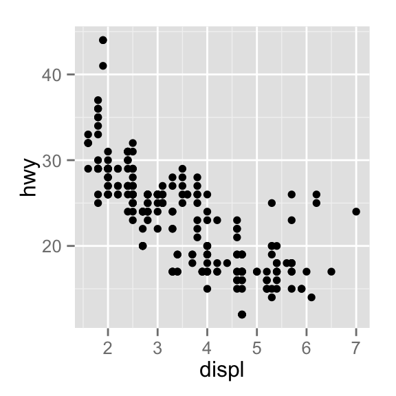

```r
qplot(displ, hwy, data = mpg)
```

We can make the same plot in a slightly longer fashion, but have more control over the plots. In this example *ggplot* is our base layer. *geom_point* is a layer we add on top of our base layer.

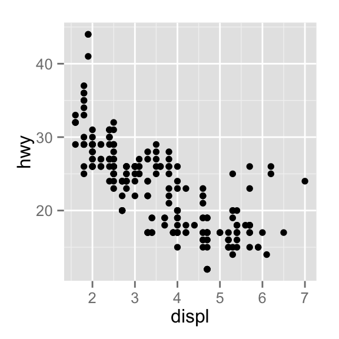

```r
# ggplot is our "base"
# geom_point is a "layer" that we add
ggplot(mpg, aes(x=displ, y=hwy)) + geom_point()
```

### aesthetics

Aesthetics make plots pretty with colors, point size, point shapes, and point gradients.

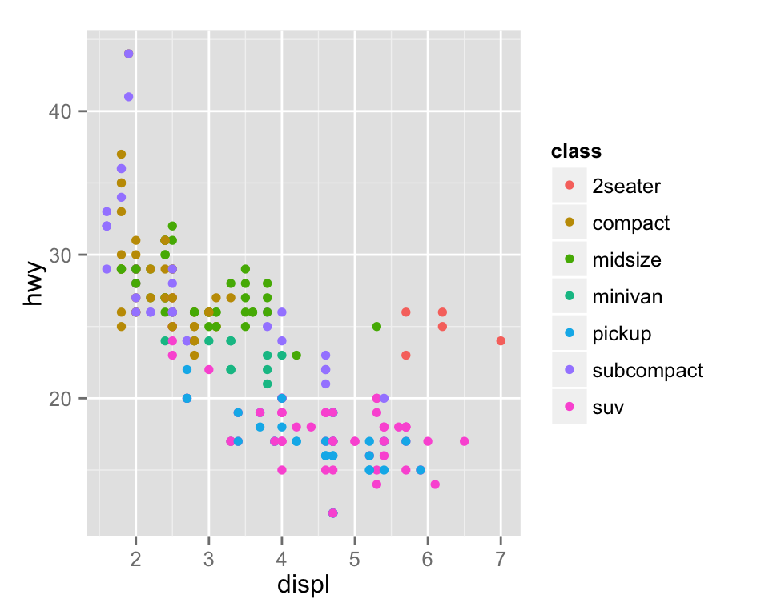

```r
# aes stands for aesthetics you can set alot of different things here.
# add color
ggplot(mpg, aes(x=displ, y=hwy, color=class)) + geom_point()
```

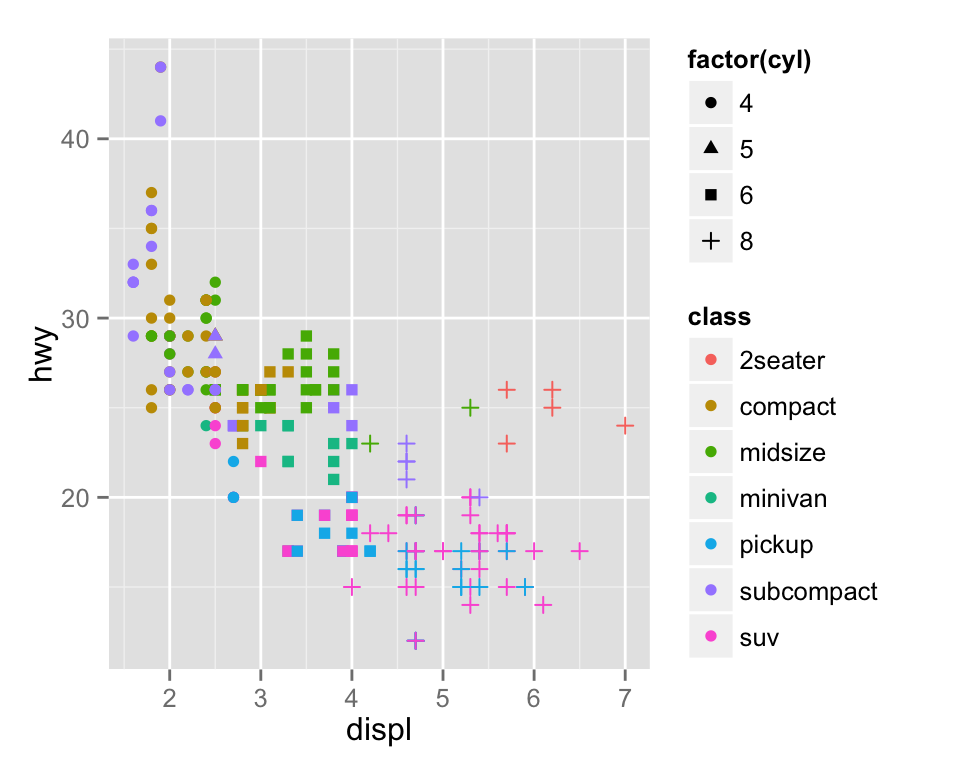

```r
# add shape
# we have to call factor because cyl is an int variable shapes are discrete
ggplot(mpg, aes(x=displ, y=hwy, color=class, shape=factor(cyl))) + geom_point()
```

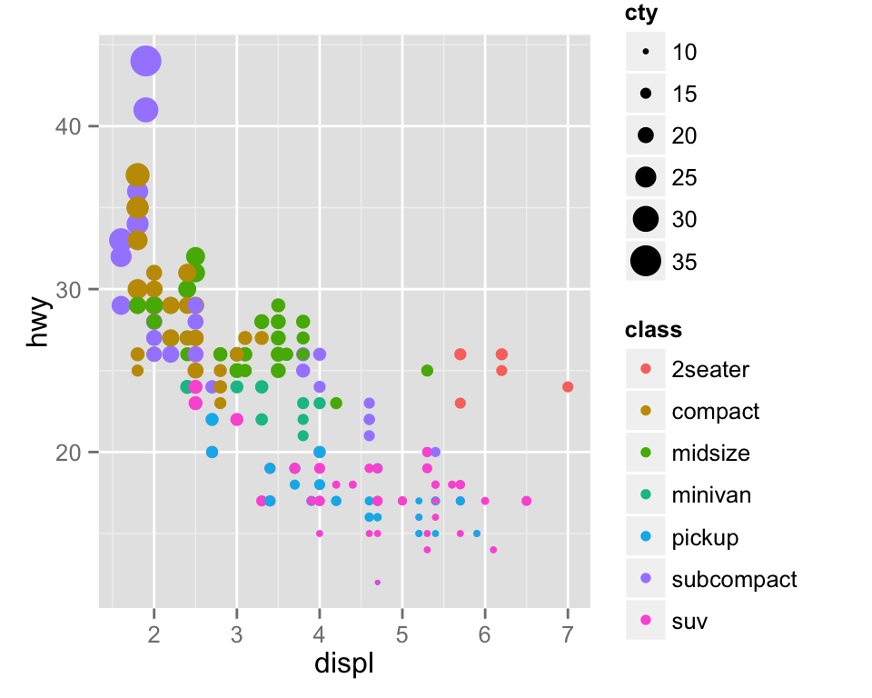

```r
# add size
ggplot(mpg, aes(x=displ, y=hwy, color=class, size=cty)) + geom_point()
```

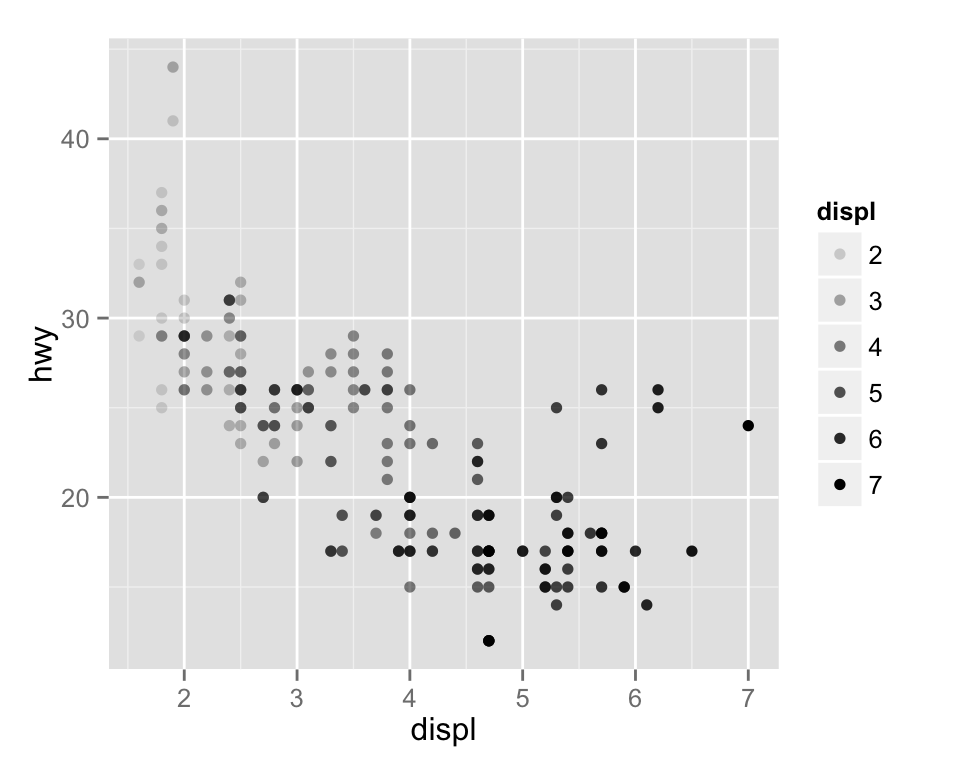

```r
# add alpha
ggplot(mpg, aes(x=displ, y=hwy, alpha=displ)) + geom_point()
```

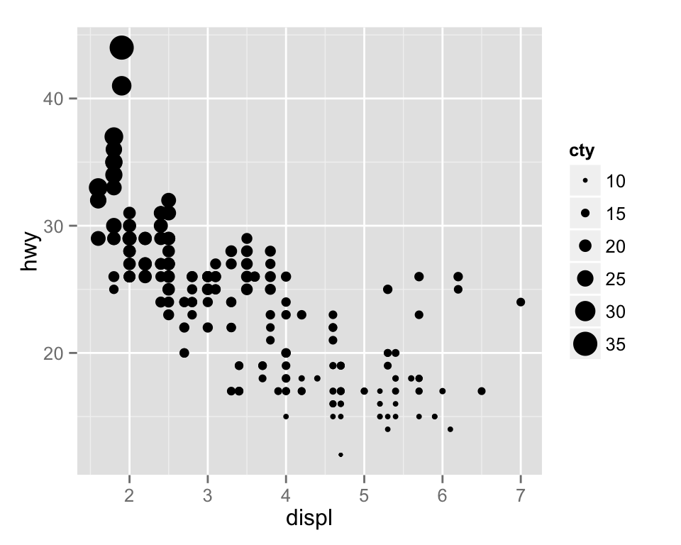

```r
# quick tip: you can move the aesthetics declaration to
# other layers. ie, aesthetics can be local instead of global
ggplot(mpg) + geom_point(aes(x=displ, y=hwy, size=cty))
```

### manipulating the plot

How to change labels, scales, and legends.

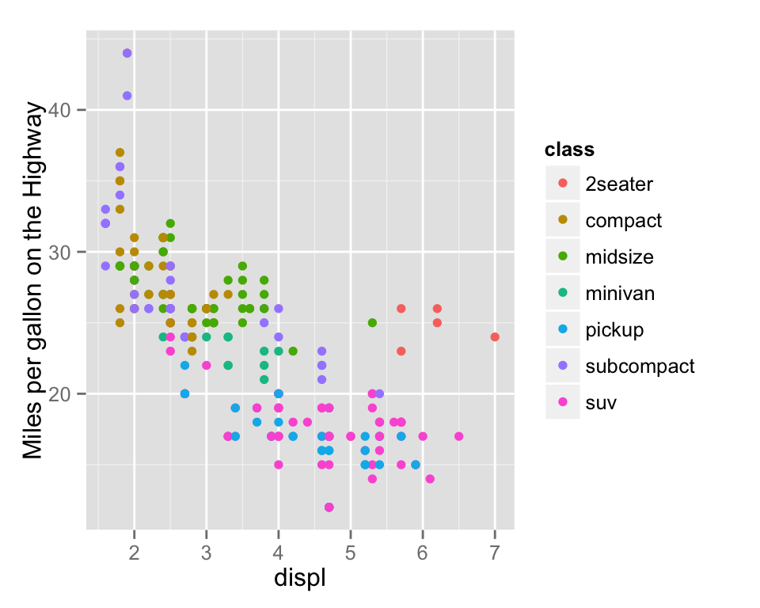

```r
# adding labels
ggplot(mpg, aes(x=displ, y=hwy, color=class)) + geom_point() + ylab("Miles per gallon on the Highway")
```

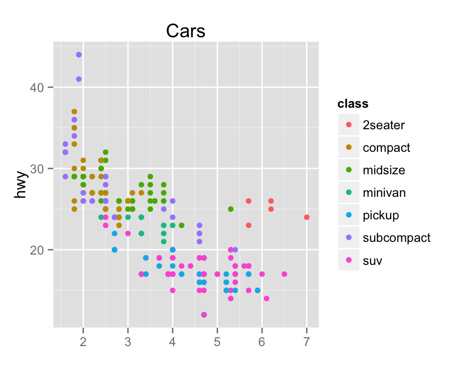

```r
ggplot(mpg, aes(x=displ, y=hwy, color=class)) + geom_point() + ggtitle("Cars") + xlab("")
```

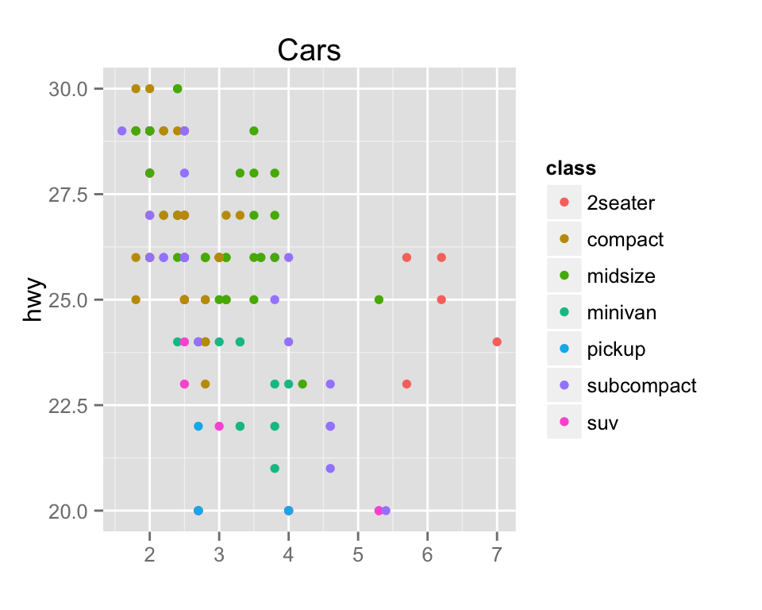

```r
# changing scales
last_plot() + ylim(20, 30)
```

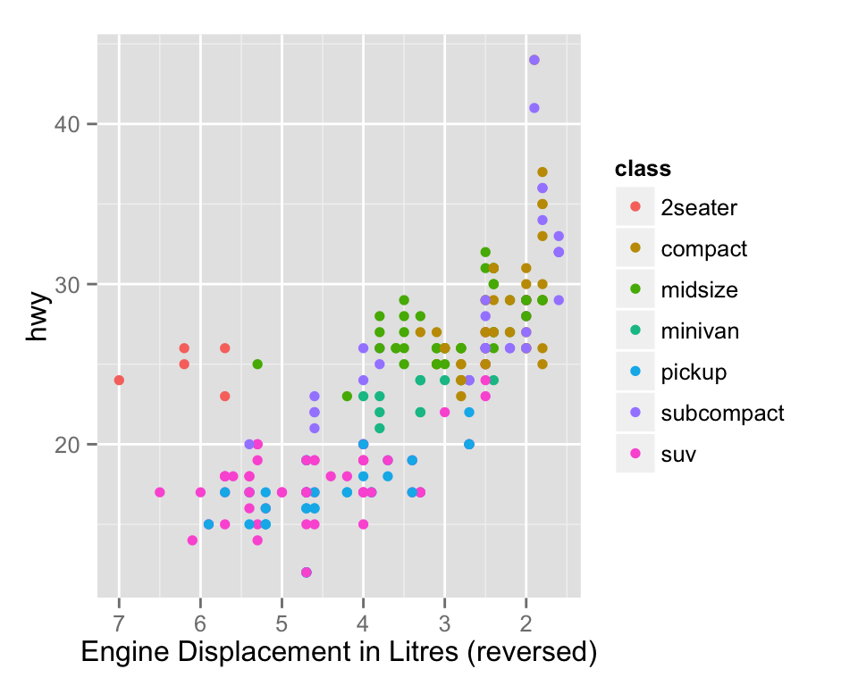

```r
ggplot(mpg, aes(x=displ, y=hwy, color=class)) + geom_point() + scale_x_reverse("Engine Displacement in Litres (reversed)")
```

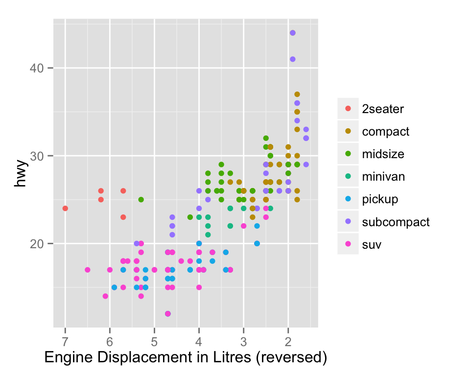

```r
# playing with legends
last_plot() + guides(color=guide_legend(title=NULL))
```

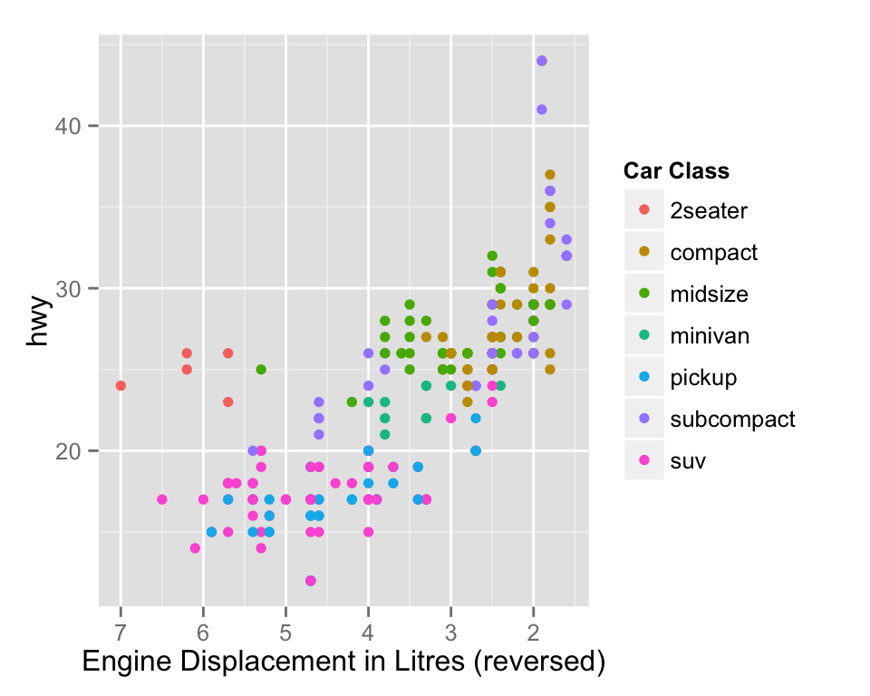

```r
last_plot() + guides(color=guide_legend(title="Car Class"))
```

### saving your plot

How to save your beautiful plots.

```r
# ggsave is a high level saving function that will figure stuff out for you
# (e.g. image size, image format).
#  it will default to save the last plot you generated
ggsave("cars.pdf")

# PDFs - the file records information on each point
# if you have many points in a scatterplot dont use this
#
# # dev.off() says stop writing to your pdf
pdf(file="cars01.pdf", height=5, width=6)
    ggplot(mpg, aes(x=displ, y=hwy, color=class)) + geom_point()
    ggplot(mpg, aes(x=displ, y=hwy, size=class)) + geom_point()
dev.off()

# PNGs - use if you have many datapoints
# below are good default settings
png(file="cars.png", width=1000, height=700, units='px', res=120)
    ggplot(mpg, aes(x=displ, y=hwy, color=class)) + geom_point()
dev.off()
```

# Bioconductor for visualizating high-throughput genomics data

Bioconductor is a repository for R packages related to bioinformatics http://www.bioconductor.org/ .

> Bioconductor provides tools for the analysis and comprehension of high-throughput genomic data. Bioconductor uses the R statistical programming language, and is open source and open development. It has two releases each year, 934 software packages, and an active user community.

The Bioconductor / R combination is very powerful. Here are some example applications:

- Visualize high-throughput genomics data
- Differential gene expression analysis
- Gene ontology enrichment
- Workflows for analyzing variants, epigenomics data (e.g. ChIP-seq), transcriptome data…
- Applying machine learning techniques to biological data

Useful Resources:

- Demo workflows - http://www.bioconductor.org/help/workflows/
- Scalable Genomics with R and Bioconductor - http://arxiv.org/abs/1409.2864

## install Bioconductor packages

```r
source("http://bioconductor.org/biocLite.R")
biocLite()

# install the GenomicRanges package
# The GenomicRanges package serves as the foundation for representing
# genomic locations within the Bioconductor project.
# You can read more about it later
biocLite("GenomicRanges")

library("GenomicRanges")
vignette("GenomicRangesIntroduction")
```

## Bioconductor package examples

### graphics

Sushi is a great bioconductor package for genomics. These examples are taken from the package vignette (http://www.bioconductor.org/packages/release/bioc/html/Sushi.html).

```r
# install the package if you have not already
biocLite("Sushi")
```

```r
# load the package
library(Sushi)
```

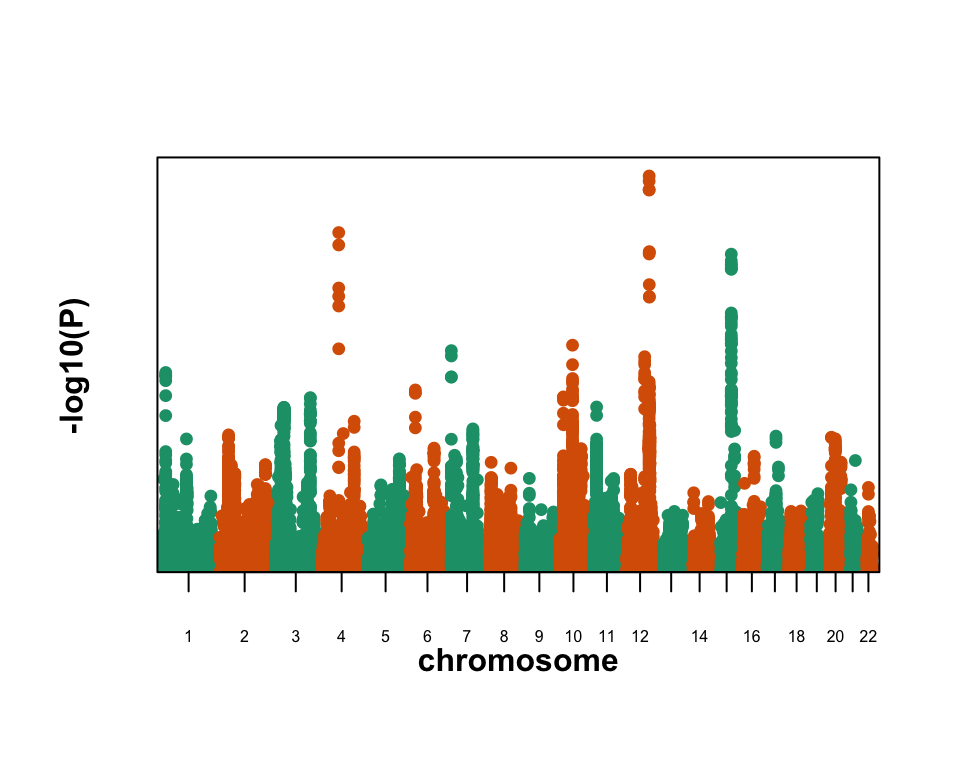

```r
# load some data included in the Sushi package
Sushi_data = data(package = 'Sushi')
data(list = Sushi_data$results[,3])

# a basic manhattan plot
plotManhattan(bedfile=Sushi_GWAS.bed, pvalues=Sushi_GWAS.bed[,5],
              col=c("#1b9e77", "#d95f02"), genome=Sushi_hg18_genome, cex=0.75)
labelgenome(genome=Sushi_hg18_genome, n=4,scale="Mb",
            edgeblankfraction=0.20, cex.axis=.5)
mtext("-log10(P)", side=2, line=1.75, cex=1, font=2)
mtext("chromosome", side=1, line=1.75, cex=1, font=2)
```

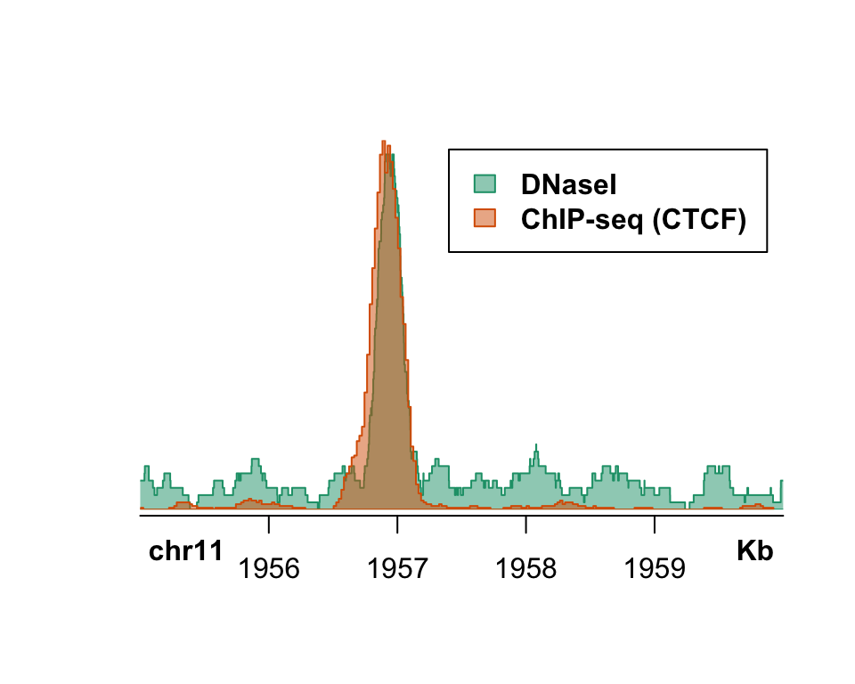

```r
# plot bed graph signal
chrom            = "chr11"
chromstart       = 1955000
chromend         = 1960000
plotBedgraph(Sushi_ChIPSeq_CTCF.bedgraph, chrom, chromstart, chromend,
             transparency=.50, color=c("#1b9e77"))
plotBedgraph(Sushi_DNaseI.bedgraph, chrom, chromstart, chromend,
             transparency=.50, color=c("#d95f02"), overlay=TRUE,
             rescaleoverlay=TRUE)
labelgenome(chrom, chromstart, chromend, n=3, scale="Kb")
legend("topright", inset=0.025, legend=c("DNaseI","ChIP-seq (CTCF)"),
       fill=opaque(c("#1b9e77", "#d95f02")), border=c("#1b9e77", "#d95f02"),
       text.font=2, cex=1.0)
```

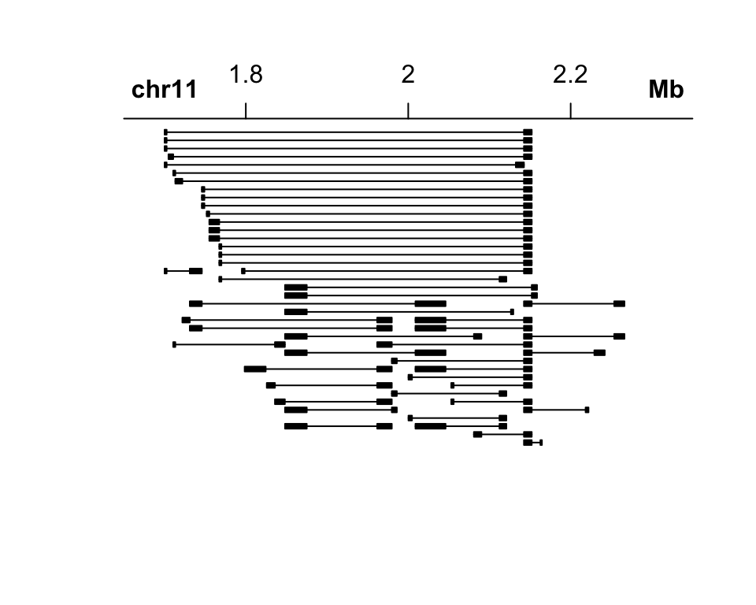

```r
# plot 5C interacting regions
chrom            = "chr11"
chromstart       = 1650000
chromend         = 2350000
pbpe = plotBedpe(Sushi_5C.bedpe, chrom, chromstart, chromend, flip=TRUE,
                 plottype="lines")
labelgenome(chrom, chromstart, chromend, side=3, n=3, scale="Mb")
```